# Data cleaning and exploration

*Jody Daniel* • *2020-10-12*

# Traits and Plant Growth Rates

We have two datasets: 1) basal area each year from 2006 to 2011 and 2) plant and environmental traits for each tree. Below, I aim to examine the data - assess data types, check for missingness, normality, outliers. Depending on the degree of missingness, I will impute the data as we would like to keep as many observations as possible.

## Table of Contents

```r
library(corrplot)
library(fastDummies)
library(RColorBrewer)
library(factoextra)
library(ggplot2)
require(ggrepel)
library(knitr)
library(kableExtra)
library(tidyverse)
library(dplyr)
library(here)
library(skimr)
library(reshape2)
library(tidymodels)
library(qdapTools)
library(rsample)
library(corrr)
library(broom)
library(vegan)
library(extrafont)
library(viridis)
library(car)
library(mice)
library(sjmisc)
library(RVAideMemoire)
source(here("scripts/archive/1. functions.R"))
theme_set(theme_special())
```

```r
rgr_raw <- read.csv(here("data/RGR.csv"))
msh_raw <- read.csv(here("data/MSH.csv"))
```

## Including Plots

Might be best to just drop some the columns trait values with a large % of missing data.

For the trait data, I will simply remove those with a majority of missing cases before running the imputation - I am thinking of using a cut of less than 50%.

```r
# removing cases with a bunch of zeroes
MSH.50 <- msh_raw[,names(which(sapply(colnames(msh_raw), function (x) {sum(is.na(msh_raw[,x]))/nrow(msh_raw)<0.5})))]
# I only want columns that are numeric
numeric_columns_msh <- which(apply(MSH.50,2, function (x) !is.na(mean(as.numeric(x), na.rm = TRUE))))
numeric_columns_rgr <- which(apply(rgr_raw,2, function (x) !is.na(mean(as.numeric(x), na.rm = TRUE))))
# I read somewhere that p>5 does not change the overall values significantly So, I will stick to that number of datasets.
MSH.IP.MICE <- mice(data.matrix(MSH.50[,numeric_columns_msh]),
               printFlag = FALSE, method = "pmm", m = 5, seed = 300)
```

Now, I will run the imputation on these data. Since I have removed the columns with a large amount of missing cases, the imputation should work. If not, I will set a more stringent condition.

```r
# fit a lm and see if results are comparable between mice output and raw data
summary(lm(Tree.Height ~ Soil.Depth + Biomass1 + Soil.Humidity + pH, data = MSH.50))
```

```
##
## Call:
## lm(formula = Tree.Height ~ Soil.Depth + Biomass1 + Soil.Humidity +
##     pH, data = MSH.50)
##
## Residuals:
##     Min      1Q  Median      3Q     Max
## -304.41 -101.11  -18.78   91.56  495.91
##
## Coefficients:
##               Estimate Std. Error t value Pr(>|t|)
## (Intercept)   385.9302    60.8228   6.345 9.97e-10 ***
## Soil.Depth      0.3963     0.5551   0.714    0.476
## Biomass1       19.4801     4.7410   4.109 5.35e-05 ***
## Soil.Humidity  89.0918    54.2310   1.643    0.102
## pH             -0.7311    11.1843  -0.065    0.948
## ---
## Signif. codes:  0 '***' 0.001 '**' 0.01 '*' 0.05 '.' 0.1 ' ' 1
##
## Residual standard error: 132.4 on 257 degrees of freedom
##   (133 observations deleted due to missingness)
## Multiple R-squared:  0.08433,    Adjusted R-squared:  0.07008
## F-statistic: 5.917 on 4 and 257 DF,  p-value: 0.0001435
```

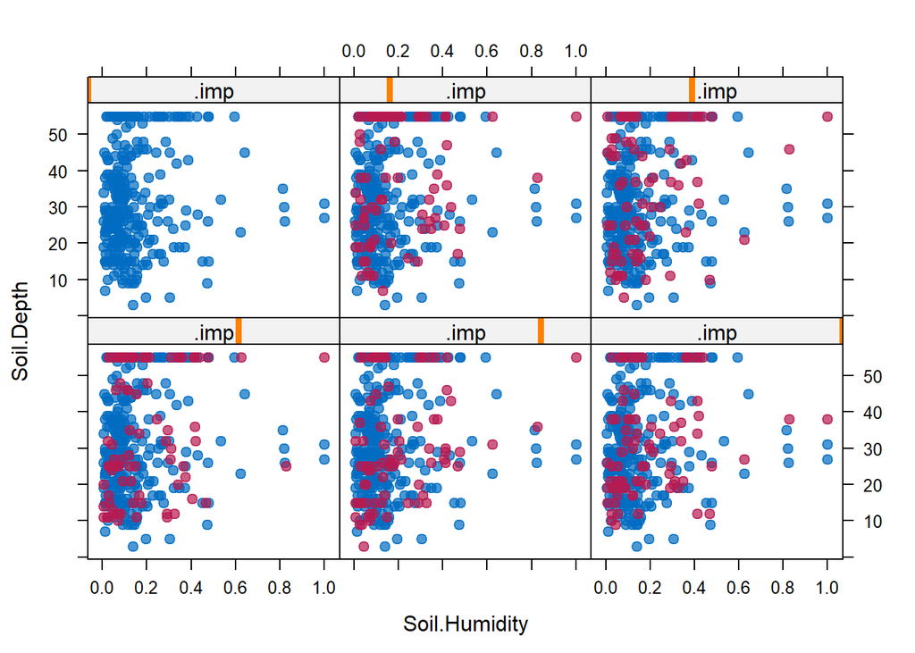

```r
# how do the combined and imputed datasets compare?
xyplot(MSH.IP.MICE, Soil.Depth ~ Soil.Humidity|.imp, pch = 20, cex = 1.4)
```

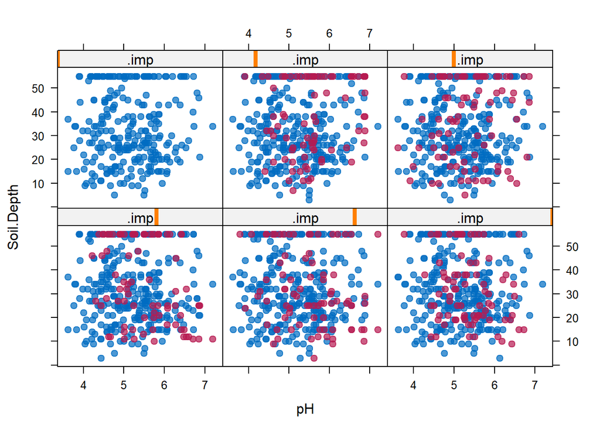

```r
xyplot(MSH.IP.MICE, Soil.Depth ~ pH|.imp, pch = 20, cex = 1.4)
```

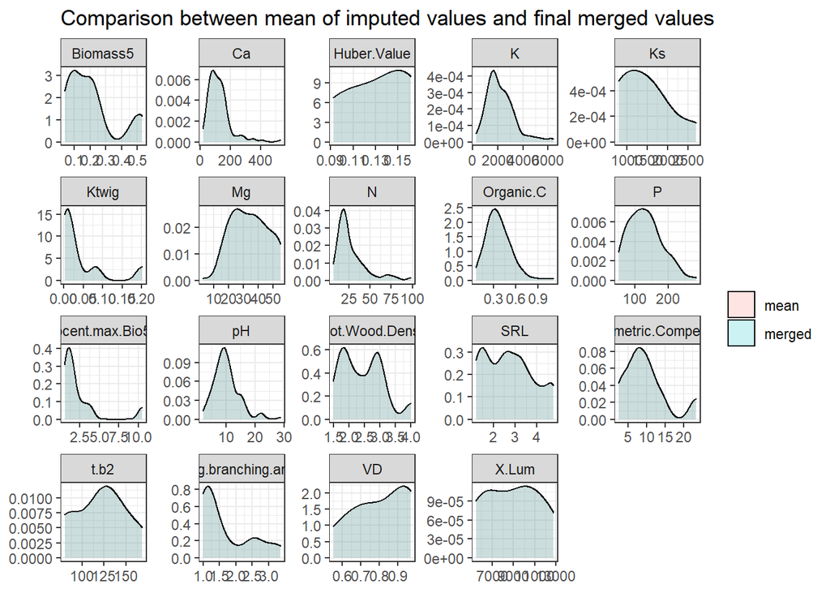

```r
#The imputed data seems to match that of the raw data. Now, how do the combined imputed data compare to the 5 datatsets from the imputation.
merge_imputations(msh_raw, MSH.IP.MICE, summary =  "dens")
```

There is strong overlap between the mean and merged values. As such, I can be confident that the merged data set is representative of individual imputations.

```r
library(abind)
MSH.IP.List <- list()
m_length <- MSH.IP.MICE$m
for (i in 1:m_length){
    MSH.IP.List[[i]] <- mice::complete(MSH.IP.MICE, action = i)}
MSH.IP.Final <- data.frame(apply(abind(MSH.IP.List, along=3), c(1,2), mean))
```

# Estimate Growth Rate

```r
# makes more sense to name the rows by their sample ID as a unique identifier
MSH.IP.Final$SampleID <- rgr_raw[,1]

MSH.RGR_IMP <- merge(rgr_raw,MSH.IP.Final, by = "SampleID")
MSH.RGR <- merge(rgr_raw,MSH.50, by = "SampleID")
# now for growth rate parameters
BAI_GR <- with(data = MSH.RGR_IMP, exp = ((BA.0.2011 - BA.0.2006)/5))
BIO_Gain <- with(data = MSH.RGR_IMP,
    exp = ((BA.0.2011*Stem.Wood.Density*Tree.Height*3)-(BA.0.2006*Stem.Wood.Density*(Tree.Height/Tree.Age*(Tree.Age-6))*3)))
BIO_2006 <- with(data = MSH.RGR_IMP,
                 exp = (BA.0.2006*Stem.Wood.Density*(Tree.Height/Tree.Age*(Tree.Age-6))*3))
BIO_GR <- BIO_Gain/((BIO_2006+1)*5)
# wanna place species and site at the start of the data frame
site_species <- c("SampleID", "Site", "Species", "Porosity")
site_species_no <- which(colnames(MSH.50)%in%site_species)
site_BA <- c(colnames(rgr_raw)[-1], "SampleID")
site_BA_no <- which(colnames(MSH.RGR_IMP)%in%site_BA)

RGR_MSH_Final <- data.frame(MSH.50[,site_species_no], BAI_GR = BAI_GR,
                           BIO_GR = BIO_GR,
                           MSH.RGR_IMP[,-site_BA_no])

# now for growth rate parameters
BAI_GR_NA <- with(data = MSH.RGR, exp = ((BA.0.2011 - BA.0.2006)/5))
BIO_Gain_NA <- with(data = MSH.RGR, exp = ((BA.0.2011*Stem.Wood.Density*Tree.Height*3) - (BA.0.2006*Stem.Wood.Density*(Tree.Height/Tree.Age*(Tree.Age-6))*3)))
BIO_2006_NA <- with(data = MSH.RGR, exp = (BA.0.2006*Stem.Wood.Density*(Tree.Height/Tree.Age*(Tree.Age-6))*3))
BIO_GR_NA <- BIO_Gain_NA/((BIO_2006_NA+1)*5)

RGR_MSH_NA_Final <- data.frame(MSH.50[,site_species_no], BAI_GR = BAI_GR_NA,
                           BIO_GR = BIO_Gain_NA,
                           MSH.50[,numeric_columns_msh])


write_csv(RGR_MSH_Final,here("data/RGR_MSH.csv"))
write_csv(RGR_MSH_NA_Final,here("data/RGR_MSH_NA.csv"))
```